# Text Prediction - Milestone report

# Executive summary

In order to build a predictive algorithm for typed text, three datasets must be analysed to discover relationships between words and group of words. These datasets contain several sentences and millions of words, and cover three semantics fields :

- a twitter dataset, with short sentences and lots of abbreviations,
- a blog dataset, with more longer sentences and a different vocabulary,
- a news datasets, with another different vocabulary.

- the common words aren’t removed, as people write them and wish to have predictions after them.
- words are stemmed (shortened to their root), in order to have some predictions as soon as the root of the word is typed.
- the raws datasets aren’t merged, but a random sample of each of them is taken, in order to cover the three semantics fields, then merged.

Finally, this choices will lead to the next step of the project : building the predictive algorithm.  
The study show that a predictive model filtering a (n+1)grams as user type n words could work. All code is available at the end of the report.

# Datas overview

## What are the datas ?

Example of the datas provided and some stats about the number of words, which are of interest for predictive text purposes.

Example of lines for each datasets are shown below :

```
[1] "How are you? Btw thanks for the RT. You gonna be in DC anytime soon? Love to see you. Been way, way too long."
```

```
[1] "In the years thereafter, most of the Oil fields and platforms were named after pagan “gods”."
```

```
[1] "He wasn't home alone, apparently."
```

And some quick exploratory of the numbers of words for each lines and for each datasets is shown below :

|  | total.Lines | total.words | mean.word.by.line | sd.of.mean | max.word.by.line |
| --- | --- | --- | --- | --- | --- |
| twit | 2,360,148 | 31,003,544 | 13.14 | 7.12 | 47 |
| blog | 899,288 | 38,309,620 | 42.60 | 47.43 | 6,851 |
| news | 1,010,242 | 35,624,454 | 35.26 | 23.37 | 1,928 |

As numbers of words are quite important, the work will be done on a sample with a good representativeness of the total datas. The following hypothesis are done too :

- the vocabulary and the semantics fields are different between each datasets
- the twit dataset should contains more typo and abbreviations than the two others, because of the character limitation of twitter

The samples randomly take 100,000 lines from each datasets, to cover each semantic field, then merged into a global sample. The statistics summary of the global sample is shown below :

|  | total.words | mean.word.by.line | sd.of.mean | max.word.by.line |
| --- | --- | --- | --- | --- |
| twitTest | 1,313,052 | 13.13 | 7.11 | 37 |
| blogTest | 4,254,158 | 42.54 | 46.57 | 2,060 |
| newsTest | 3,519,074 | 35.19 | 23.11 | 729 |

## PreProcessing - cleaning datasets

In order to show the most frequent words, a cleaning must be done to avoid noise with uppercase, punctuation, typos or numbers.  
All the code of the cleaning is available at the end of the report.

# Exploratory Analysis

## Frequencies of words

### Most commons words

As seen below the results aren’t very interesting, because the most commons words are… common words, like ‘the’ or ‘a’ or ‘and’. But they are needed as users type them and might need a prediction for them. Studying the distribution of only one word is not enough for a predictive software.

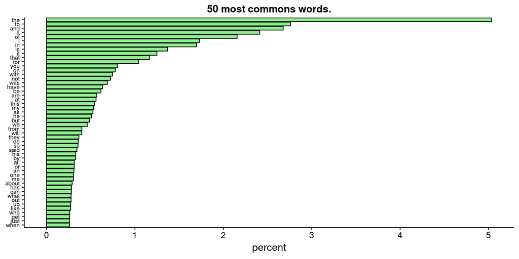

### Minimum unique words to cover distribution

Some interesting results : the numbers of unique words to describe 90 % of the total words is not so important, as seen in the following plots and tables.

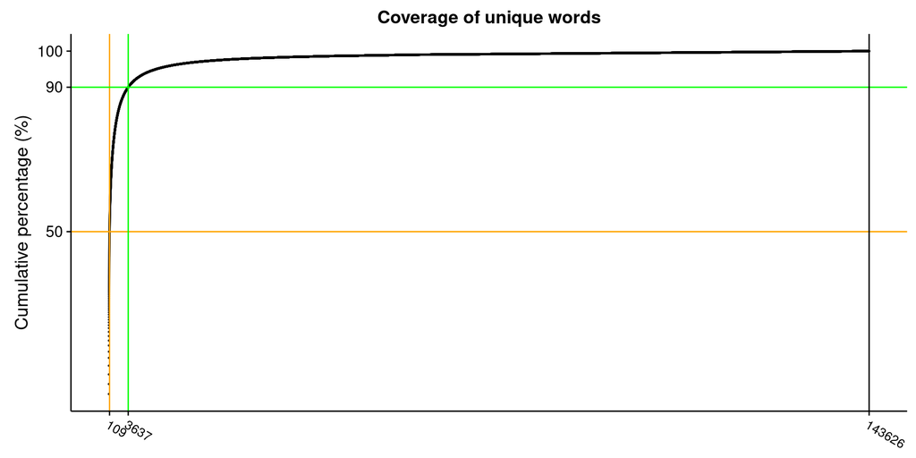

[output not shown]

*It might be possible to have a good prediction for only few uniques words, as they cover most of the uses.*  
The next step is to study the associations of words in the dataset, to begin to think of a predictive model.

## Terms associations

### 2 and 3-grams

To study associations of words, it’s useful to check the ‘n-grams’, which are groups of n words. As for unique words, the mosts commons n-grams and the minimum unique n-grams to cover 90 % of the distribution will be studied.  
Then a map of words associations can be plotted.

Distributions of most commons bigrams and trigrams, without any filter :

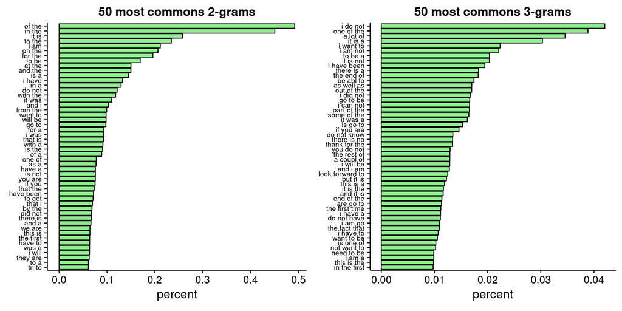

Another way to represent words associations are shown below : associations seems to be more “precise” as n increase.  
**Plot of relationship between words based on bigrams :**

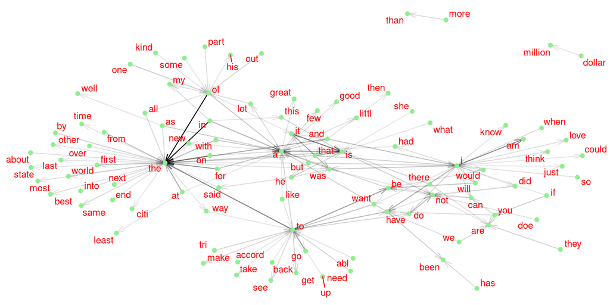

**Plot of relationship between words based on trigrams :**

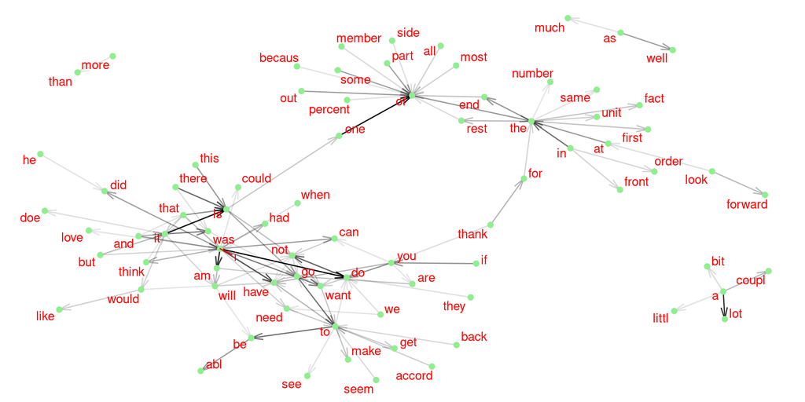

Some interesting results, by filtering bigrams beginning by ‘love’, then filtering trigrams by ‘love you’.

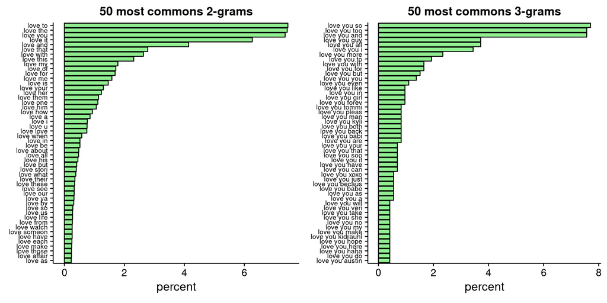

*Some predictions possibilities begin to appear, for example by filtering bigrams by the first word typed by the user, then filtering trigrams by the two words typed by user, and so on, and choosing the first three results of each.*  
But a problem appears too : the numbers of ngrams necessary to cover the distribution increase with n, as shown in the followings plots. The calculations might be very long with large n.

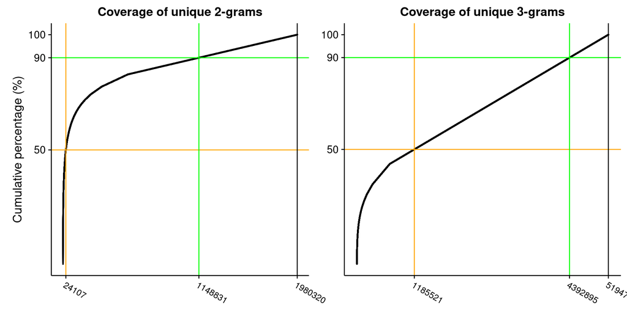

|  | 50 percent | 90 percent | total unique ngrams |
| --- | --- | --- | --- |
| Number of unique 2-grams | 24,107 | 1,148,831 | 1,980,320 |
| Number of unique 3-grams | 1,185,521 | 4,392,895 | 5,194,738 |

# Future

All the difficulty is to have the most precise prediction as possible, but also as quick as possible.  
The preliminary study show that a predictive model could work : as the user type n words, find the most common (n+1)grams corresponding to the typed words. This model could adapt itself to the user, by adding new typed words in the datasets.

So the future studies consists of :

- finding the best (n+1)grams to permit accuracy and quick response.
- trying ngrams with only the words necessary to cover 90 % of the datasets, to lower the number of possible ngrams, and so increase response speed.

## Sources

Source : [tidytextmining.com](http://tidytextmining.com/)

# Code Resume

## Libraries

```r
library(cowplot) # mutiple ggplot
library(data.table)
library(dplyr)
library(ggplot2)
library(ggraph) # plot words relationship
library(igraph) # plot words relationship
library(knitr)
library(qdap) # cleaning text
library(RColorBrewer)
library(stringr) # wordcount
library(tidyr) # separate words of ngrams into columns
library(tidytext) # for tidy analysis of texts
library(wordcloud)
```

## Functions

```r
############################################################
# OVERVIEW
############################################################
overview <- function(texte) {
    data.frame(total.Lines=length(texte), total.words=sum(str_count(texte,'\\w+')),
               mean.word.by.line=mean(str_count(texte,'\\w+')),
               sd.of.mean=sd(str_count(texte,'\\w+')),
               max.word.by.line=max(str_count(texte,'\\w+')))
}

# overview for multiple files
multiOverview <- function(liste) {
    # take a list of character containing names of text variables, then return a
    # dataframe of stats
    dataSumList <- lapply(liste, function(x) overview(get(x)))
    len <- length(liste)
    dataSum <- data.frame()
    for(i in 1:len) {
        dataSum <- rbind(dataSum, dataSumList[[i]])
    }
    row.names(dataSum) <- liste
    dataSum
}

############################################################
# CREATE TIDY NGRAMS
############################################################
tidyNGram <- function(texte, lang="en", rmStopword=FALSE, stemwords=TRUE, n.gram=1) {
    # take a text file, and return a possibly clean without stopwords and stemmed
    # tidy table depending if chosen options
    library(data.table)
    library(tidytext)
    library(dplyr)
    library(qdap)
    # cleaning sentences
    texte <- texte %>%
        replace_contraction() %>%
        tolower() %>%
        replace_number(remove=TRUE) %>%
        replace_ordinal(remove=TRUE) %>%
        replace_symbol() %>% replace_abbreviation()

    # remove stopwords option
    if(rmStopword==TRUE){
        texte <- rm_stopwords(texte, separate=FALSE)
    }
    # stemming option
    if(stemwords==TRUE){
        texte <- stemmer(texte)
    }
    # transforms list in tidy table
    len <- length(texte)
    textFile <- data.table()
    textFile <- data.table(line=1:len, text=texte)
    tidyText <- textFile %>%
        unnest_tokens(ngram, text, token="ngrams", n=n.gram)
    tidyText
}

############################################################
# PLOT MOST COMMON NGRAMS
############################################################
countPlot <- function(tidyText, nb=50){
    # take a tidyText a plot the n most commons words or ngrams with ggplot
    library(dplyr)
    library(ggplot2)
    nbgram <- str_count(tidyText$ngram[1], '\\w+')
    if(nbgram==1){
        graphTitle <- paste(nb, "most commons words.")
    } else {
        graphTitle <- paste(nb, " most commons ",nbgram,"-grams", sep="")
    }
    tidyText %>%
        count(ngram, sort=TRUE) %>%
        mutate(ngram=reorder(ngram,n)) %>%
        mutate(percent=n/sum(n)*100) %>%
        # splitting to plot nb words
        slice(1:nb) %>%
        # plot the plot
        ggplot(aes(ngram,percent)) +
        geom_bar(stat="identity", fill="lightgreen", color="black") +
        xlab(NULL) +
        ggtitle(graphTitle) +
        theme(axis.text.y = element_text(size=8)) +
        coord_flip()
}

############################################################
# PLOT WORDCLOUD
############################################################
wordCloudPlot <- function(tidyText, nb=100) {
    # take a tidyText and plot a wordCloud of n most common words or ngrams
    library(wordcloud)
    library(RColorBrewer)
    tidyText <- tidyText %>% count(ngram, sort=TRUE)
    wordcloud(words=tidyText$ngram, freq=tidyText$n, max.words=nb, random.order=F,
              rot.per=0.35, scale=c(5,0.5), colors=brewer.pal(8,"Dark2"))
}

############################################################
# PLOT NGRAM COVERAGE
############################################################
coverWords <- function(tidyText, n1=50, n2=90) {
    # take a tidyText and return a data.frame with numbers of unique words to describe
    # n1 and n2 % of the total dataset.
    library(dplyr)
    tidyText <- tidyText %>% count(ngram, sort=TRUE) %>%
        mutate(ngram=reorder(ngram,n)) %>%
        mutate(percent=n/sum(n)*100) %>%
        mutate(cumulative_percent=cumsum(percent))

    # select first row which are greater than n1 and n2
    x1 <- which(tidyText$cumulative_percent>n1)[1]
    x2 <- which(tidyText$cumulative_percent>n2)[1]
    results <- data.frame(x1,x2, dim(tidyText)[1])

    name.x1 <- paste(n1,"percent")
    name.x2 <- paste(n2,"percent")

    # part to chose if words or ngrams (for labs and title)
    nbgram <- str_count(tidyText$ngram[1], '\\w+')
    if(nbgram==1){
        names(results) <- c(name.x1, name.x2, 'total unique words')
        row.names(results) <- "Number of unique words"
    } else {
        name.x3 <- "total unique ngrams"
        names(results) <- c(name.x1, name.x2, name.x3)
        row.names(results) <- paste("Number of unique ",nbgram,"-grams", sep="")
    }
    results
}

cumulativePlot <- function(tidyText, n1=50, n2=90) {
    # take a tidyText and plot a cumulative plot with nb of unique words to cover
    # n1 and n1 % of total words
    library(dplyr)
    tidyText <- tidyText %>% count(ngram, sort=TRUE) %>%
        mutate(ngram=reorder(ngram,n)) %>%
        mutate(percent=n/sum(n)*100) %>%
        mutate(cumulative_percent=cumsum(percent))

    # select first row which are greater than n1 and n2
    x1 <- which(tidyText$cumulative_percent>n1)[1]
    x2 <- which(tidyText$cumulative_percent>n2)[1]
    x3 <- dim(tidyText)[1]

    # part to chose if words or ngrams (for labs and title)
    nbgram <- str_count(tidyText$ngram[1], '\\w+')
    if(nbgram==1){
        xLab <- "Number of unique words"
        graphTitle <- "Coverage of unique words"
    } else {
        xLab <- paste("Number of unique ",nbgram,"-grams", sep="")
        graphTitle <- paste("Coverage of unique ",nbgram,"-grams", sep="")
    }

    tidyText %>%
        ggplot(aes(1:nrow(tidyText), cumulative_percent)) +
        geom_point(size=0.2) + xlab(NULL) + ggtitle(graphTitle) +
        ylab("Cumulative percentage (%)") +
        geom_hline(yintercept=n1, col="orange") +
        geom_vline(xintercept=x1, col="orange") +
        geom_hline(yintercept=n2, col="green") +
        geom_vline(xintercept=x2, col="green") +
        geom_vline(xintercept=x3, col="black") +
        scale_x_continuous(breaks=c(x1,x2,x3)) +
        theme(axis.text.x=element_text(angle=-30, hjust=0, size=10)) +
        scale_y_continuous(breaks=c(n1,n2,100))
}
############################################################
# PLOT RELATIONSHIP BETWEEN NGRAMS
############################################################
relationPlot <- function(tidyText, nb=100) {
    library(igraph)
    library(ggraph)
    library(stringr)
    library(tidyr)
    # take a tidy ngram and plot relationship between the nb most common words
    # separate column and prepare for plotting
    nbCol <- str_count(tidyText$ngram[1], '\\w+')
    name <- NULL
    for(i in 1:nbCol){
        name <- c(name,paste("word",i, sep=""))
    }
    tidyText <- tidyText %>%
        count(ngram, sort=T) %>%
        # separate words to plot relationship
        separate(col=ngram, into=name, sep=" ") %>%
        # split to plot only nb words
        slice(1:nb) %>%
        graph_from_data_frame()

    # plot relationship between words
    a <- grid::arrow(type="open", angle=15, length=unit(.15, "inches"))
    ggraph(tidyText, layout="fr") +
        geom_edge_link(aes(edge_alpha=n), show.legend=FALSE, arrow=a) +
        geom_node_point(color="lightgreen", size=2) +
        geom_node_text(aes(label=name), repel=TRUE, color="red") +
        theme_void()
}
```

by Bruno Berrehuel